# Data Cleaning

Emmett McIntosh

2026-08-21

```r
library(tidyverse)
library(lubridate)
```

Function that reads one participant’s HR file:

```r
read_hr = function(file, subject, exercise) {
  #read file without assuming column names
  raw = read_csv(file, col_names = FALSE, show_col_types = FALSE)
  #first row = start time
  start_time = ymd_hms(raw[[1]][1], tz = "UTC")
  #second row = sampling frequency
  sample_rate = as.numeric(raw[[1]][2])
  #remaining rows = HR measurements
  hr = as.numeric(raw[[1]][3:nrow(raw)])
  #construct dataset
  tibble(
    subject = subject,
    exercise = exercise,
    session_time = seq(0, by = 1 / sample_rate, length.out = length(hr)),
    timestamp = start_time + session_time,
    HR = hr
  )
}
```

R can automatically process every folder with this function:

```r
read_exercise_folder = function(folder, exercise_name) {
  subject_folders = list.dirs(folder, recursive = FALSE, full.names = TRUE)
  map_dfr(subject_folders, function(subject_folder) {
    subject = basename(subject_folder)
    hr_file = file.path(subject_folder, "HR.csv")
    #skip folder if HR.csv doesn't exist
    if (!file.exists(hr_file)) {
      return(NULL)
    }
    read_hr(file = hr_file, subject = subject, exercise = exercise_name
    )
  })
}
```

Now run this block corresponding to my file directory:

```r
aerobic_path = "/Users/emmettmcintosh/Personal Projects/Modeling HR and Recovery Post-Exercise/Dataset/wearable-device-dataset-from-induced-stress-and-structured-exercise-sessions-1.0.1/Wearable_Dataset/AEROBIC"
anaerobic_path = "/Users/emmettmcintosh/Personal Projects/Modeling HR and Recovery Post-Exercise/Dataset/wearable-device-dataset-from-induced-stress-and-structured-exercise-sessions-1.0.1/Wearable_Dataset/ANAEROBIC"
aerobic_hr = read_exercise_folder(aerobic_path, "Aerobic")
anaerobic_hr = read_exercise_folder(anaerobic_path, "Anaerobic")
```

Combine the two:

```r
hr_master = bind_rows(aerobic_hr, anaerobic_hr)
```

Add protocol version (S = V1, f = V2):

```r
hr_master = hr_master %>%
  mutate(
    protocol = case_when(
      str_starts(subject, "S") ~ "V1",
      str_starts(subject, "f") ~ "V2",
      TRUE ~ NA_character_
    )
  )
```

Arrange columns:

```r
hr_master = hr_master %>%
  select(
    subject,
    protocol,
    exercise,
    timestamp,
    session_time,
    HR
  )
```

Now we will create a separate dataset for tags.csv, our timestamps dataset:

```r
read_tags = function(file, subject, exercise) {
  raw = read_csv(file, col_names = FALSE, show_col_types = FALSE)
  tibble(
    subject = subject,
    exercise = exercise,
    tag_number = seq_len(nrow(raw)),
    tag_time = ymd_hms(
      raw[[1]],
      tz = "UTC"
    )
  )
}
```

Function to process every subject folder:

```r
read_tags_folder = function(folder, exercise_name) {
  subject_folders = list.dirs(folder, recursive = FALSE, full.names = TRUE)
  map_dfr(subject_folders, function(subject_folder) {
    subject = basename(subject_folder)
    tags_file = file.path(subject_folder, "tags.csv")
    if (!file.exists(tags_file)) {
      return(NULL)
    }
    read_tags(file = tags_file, subject = subject, exercise = exercise_name)
  })
}
```

Use same paths we already created:

```r
aerobic_tags = read_tags_folder(aerobic_path, "Aerobic")
anaerobic_tags = read_tags_folder(anaerobic_path, "Anaerobic")
tags_master = bind_rows(aerobic_tags, anaerobic_tags)
```

Add protocol:

```r
tags_master <- tags_master %>%
  mutate(
    protocol = case_when(
      str_starts(subject, "S") ~ "V1",
      str_starts(subject, "f") ~ "V2",
      TRUE ~ NA_character_
    )
  ) %>%
  select(
    subject,
    protocol,
    exercise,
    tag_number,
    tag_time
  )
```

Identify the folders with abnormal sessions:

```r
tag_counts = tags_master %>%
  count(protocol, exercise, subject, name = "n_tags")
tag_counts %>%
  filter(
    (protocol == "V1" & exercise == "Aerobic" & n_tags != 12) |
      (protocol == "V1" & exercise == "Anaerobic" & n_tags != 7) |
      (protocol == "V2" & exercise == "Aerobic" & n_tags != 8) |
      (protocol == "V2" & exercise == "Anaerobic" & n_tags != 11)
  ) %>%
  arrange(exercise, subject)
```

```
## # A tibble: 7 × 4
##   protocol exercise  subject n_tags
##   <chr>    <chr>     <chr>    <int>
## 1 V1       Aerobic   S03          7
## 2 V1       Aerobic   S07          9
## 3 V1       Aerobic   S11_a       10
## 4 V1       Aerobic   S11_b        1
## 5 V1       Anaerobic S06          5
## 6 V1       Anaerobic S16_a        4
## 7 V1       Anaerobic S16_b        5
```

- S03 Aer: incomplete protocol
- S07 Aer: incomplete protocol
- S11a Aer: split recording 1
- S11b Aer: split recording 2
- S06 Ana: incomplete protocol
- S16a Ana: split recording 1
- S16b Ana: split recording 2

So for the first clean version of the dataset I will exclude these 7 from their stage assignment and keep them separate for possible later reconstruction. This leaves us with a consistent dataset:

```r
clean_sessions = tag_counts %>%
  mutate(
    complete_tags = case_when(
      protocol == "V1" & exercise == "Aerobic"   & n_tags == 12 ~ TRUE,
      protocol == "V1" & exercise == "Anaerobic" & n_tags == 7  ~ TRUE,
      protocol == "V2" & exercise == "Aerobic"   & n_tags == 8  ~ TRUE,
      protocol == "V2" & exercise == "Anaerobic" & n_tags == 11 ~ TRUE,
      TRUE ~ FALSE
    )
  ) %>%
  filter(complete_tags)
```

Restrict both HR and tag datasets to these clean sessions:

```r
hr_clean = hr_master %>%
  semi_join(clean_sessions, by = c("subject", "protocol", "exercise"))
tags_clean = tags_master %>%
  semi_join(clean_sessions, by = c("subject", "protocol", "exercise"))
```

Check:

```r
count(hr_clean, protocol, exercise)
```

```
## # A tibble: 4 × 3
##   protocol exercise      n
##   <chr>    <chr>     <int>
## 1 V1       Aerobic   28552
## 2 V1       Anaerobic 18470
## 3 V2       Aerobic   31997
## 4 V2       Anaerobic 29192
```

```r
count(tags_clean, protocol, exercise)
```

```
## # A tibble: 4 × 3
##   protocol exercise      n
##   <chr>    <chr>     <int>
## 1 V1       Aerobic     168
## 2 V1       Anaerobic   112
## 3 V2       Aerobic     104
## 4 V2       Anaerobic   143
```

Tag totals verify the filtering:

- V1 Aerobic: 168/12 = 14 complete sessions
- V1 Anaerobic: 112/7 = 16 complete sessions
- V2 Aerobic: 104/8 = 13 complete sessions
- V2 Anaerobic: 143/11 = 13 complete sessions

Now we create 4 lookup tables for the protocols:

```r
#V1 AEROBIC
v1_aerobic_lookup = tribble(
  ~tag_number, ~stage,
  1,  "60rpm",
  2,  "70rpm",
  3,  "75rpm",
  4,  "80rpm",
  5,  "85rpm",
  6,  "90rpm",
  7,  "95rpm",
  8,  "100rpm",
  9,  "105rpm",
  10, "110rpm",
  11, "cooldown",
  12, "rest"
)
#V2 AEROBIC
v2_aerobic_lookup = tribble(
  ~tag_number, ~stage,
  1, "warmup",
  2, "70rpm",
  3, "75rpm",
  4, "80rpm",
  5, "85rpm",
  6, "90_95rpm",
  7, "cooldown",
  8, "rest"
)
#V1 ANAEROBIC
v1_anaerobic_lookup = tribble(
  ~tag_number, ~stage,
  1, "sprint1",
  2, "cooldown1",
  3, "sprint2",
  4, "cooldown2",
  5, "sprint3",
  6, "cooldown3",
  7, "rest"
)
#V2 ANAEROBIC
v2_anaerobic_lookup = tribble(
  ~tag_number, ~stage,
  1,  "warmup",
  2,  "sprint1",
  3,  "cooldown1",
  4,  "sprint2",
  5,  "cooldown2",
  6,  "sprint3",
  7,  "cooldown3",
  8,  "sprint4",
  9,  "cooldown4",
  10, "rest",
  11, "end"
)
```

Add identifiers to each table so R knows which lookup applies to which session:

```r
v1_aerobic_lookup = v1_aerobic_lookup %>%
  mutate(protocol = "V1", exercise = "Aerobic")
v2_aerobic_lookup = v2_aerobic_lookup %>%
  mutate(protocol = "V2", exercise = "Aerobic")

v1_anaerobic_lookup = v1_anaerobic_lookup %>%
  mutate(protocol = "V1", exercise = "Anaerobic")
v2_anaerobic_lookup = v2_anaerobic_lookup %>%
  mutate(protocol = "V2", exercise = "Anaerobic")
```

Combine them:

```r
protocol_lookup = bind_rows(
  v1_aerobic_lookup,
  v2_aerobic_lookup,
  v1_anaerobic_lookup,
  v2_anaerobic_lookup
) %>%
  select(
    protocol,
    exercise,
    tag_number,
    stage
  )
```

Attach the protocol diagrams to the time stamps:

```r
tags_labeled = tags_clean %>%
  left_join(
    protocol_lookup,
    by = c(
      "protocol",
      "exercise",
      "tag_number"
    )
  )
```

Now assign a stage to every row of hr_clean based on which two tag times it falls between. We go session-by-session using findInterval():

```r
hr_labeled = hr_clean %>%
  group_by(subject, protocol, exercise) %>%
  group_modify(~{
    current_tags = tags_labeled %>%
      filter(
        subject == .y$subject,
        protocol == .y$protocol,
        exercise == .y$exercise
      ) %>%
      arrange(tag_time)
    #find which tag interval each HR timestamp belongs to
    interval_id = findInterval(
      .x$timestamp,
      current_tags$tag_time
    )
    #stage before first tag depends on protocol
    pre_stage = case_when(
      .y$protocol == "V1" & .y$exercise == "Aerobic"   ~ "warmup",
      .y$protocol == "V1" & .y$exercise == "Anaerobic" ~ "warmup",
      .y$protocol == "V2"                               ~ "baseline",
      TRUE ~ NA_character_
    )
    stage = ifelse(
      interval_id == 0,
      pre_stage,
      current_tags$stage[pmin(interval_id, nrow(current_tags))]
    )
    .x %>%
      mutate(stage = stage)
  }) %>%
  ungroup()
```

Now create variable that resets to 0 at the beginning of every stage:

```r
hr_labeled = hr_labeled %>%
  group_by(subject, protocol, exercise, stage) %>%
  arrange(timestamp, .by_group = TRUE) %>%
  mutate(
    stage_time = as.numeric(
      difftime(
        timestamp,
        min(timestamp),
        units = "secs"
      )
    )
  ) %>%
  ungroup()
```

Now create broader variables to make sure the detailed stage labels become easier to use:

```r
hr_analysis = hr_labeled %>%
  mutate(
    stage_type = case_when(
      stage == "baseline" ~ "baseline",
      stage == "warmup" ~ "warmup",
      str_detect(stage, "rpm") ~ "aerobic_workload",
      str_detect(stage, "^sprint") ~ "sprint",
      str_detect(stage, "^cooldown") ~ "recovery",
      stage == "rest" ~ "rest",
      stage == "end" ~ "end",
      TRUE ~ "other"
    ),
    bout_number = case_when(
      str_detect(stage, "1$") ~ 1,
      str_detect(stage, "2$") ~ 2,
      str_detect(stage, "3$") ~ 3,
      str_detect(stage, "4$") ~ 4,
      TRUE ~ NA_real_
    )
  )
```

Next create recovery time variable:

```r
hr_analysis = hr_analysis %>%
  mutate(
    recovery_time = if_else(
      stage_type == "recovery",
      stage_time,
      NA_real_
    )
  )
```

At this point the analytical dataset is in good shape. We will now create a few recovery summary variables that will make the later comparisons interpretable.

For example, create the HR value at the start of each recovery period:

```r
recovery_data = hr_analysis %>%
  filter(stage_type == "recovery") %>%
  group_by(subject, protocol, exercise, stage, bout_number) %>%
  arrange(recovery_time, .by_group = TRUE) %>%
  mutate(
    recovery_start_HR = first(HR),
    HR_drop = recovery_start_HR - HR
  ) %>%
  ungroup()
```

This way, HR_drop tells us how many bpm the participant has recovered relative to the beginning of that recovery period:

$HR_{drop} (t) = HR(0) - HR(t)$

So if someone starts recovery at 155 bpm and is at 130 bpm after 60 seconds

$HR_{drop} (60) = 155 - 130 = 25bpm$

Find largest common window:

```r
windows <- c(60, 90, 120, 150, 180)

coverage_by_window <- purrr::map_dfr(windows, function(w) {

  recovery_data %>%
    filter(recovery_time >= 0,
           recovery_time <= w) %>%
    group_by(subject, protocol, exercise, bout_number) %>%
    summarise(
      min_time = min(recovery_time),
      max_time = max(recovery_time),
      n_unique_times = n_distinct(recovery_time),
      .groups = "drop"
    ) %>%
    mutate(
      window = w,
      complete = min_time == 0 &
        max_time >= w &
        n_unique_times >= (w + 1)
    )

}) %>%
  group_by(exercise, protocol, window) %>%
  summarise(
    total = n(),
    complete = sum(complete),
    percent_complete = 100 * complete / total,
    .groups = "drop"
  )

coverage_by_window
```

```
## # A tibble: 20 × 6
##    exercise  protocol window total complete percent_complete
##    <chr>     <chr>     <dbl> <int>    <int>            <dbl>
##  1 Aerobic   V1           60    14       14           100
##  2 Aerobic   V1           90    14       14           100
##  3 Aerobic   V1          120    14       14           100
##  4 Aerobic   V1          150    14       14           100
##  5 Aerobic   V1          180    14       14           100
##  6 Aerobic   V2           60    13       12            92.3
##  7 Aerobic   V2           90    13       12            92.3
##  8 Aerobic   V2          120    13        6            46.2
##  9 Aerobic   V2          150    13        1             7.69
## 10 Aerobic   V2          180    13        0             0
## 11 Anaerobic V1           60    48       47            97.9
## 12 Anaerobic V1           90    48       46            95.8
## 13 Anaerobic V1          120    48       35            72.9
## 14 Anaerobic V1          150    48       32            66.7
## 15 Anaerobic V1          180    48       32            66.7
## 16 Anaerobic V2           60    52       47            90.4
## 17 Anaerobic V2           90    52       47            90.4
## 18 Anaerobic V2          120    52       47            90.4
## 19 Anaerobic V2          150    52       47            90.4
## 20 Anaerobic V2          180    52       40            76.9
```

Now visualize it

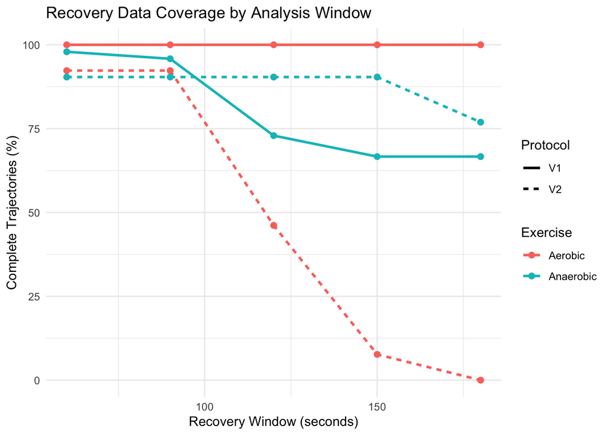

```r
ggplot(
  coverage_by_window,
  aes(
    x = window,
    y = percent_complete,
    color = exercise,
    linetype = protocol
  )
) +
  geom_line(linewidth = 1) +
  geom_point(size = 2) +
  labs(
    title = "Recovery Data Coverage by Analysis Window",
    x = "Recovery Window (seconds)",
    y = "Complete Trajectories (%)",
    color = "Exercise",
    linetype = "Protocol"
  ) +
  theme_minimal()
```

Create new recovery analysis dataset:

```r
recovery_90 = recovery_data %>%
  filter(
    recovery_time >= 0,
    recovery_time <= 90
  )
```

The datasets are now analysis ready so we save them:

```r
write_csv(hr_analysis, "/Users/emmettmcintosh/Personal Projects/Modeling HR and Recovery Post-Exercise/Processed Data/hr_analysis.csv")
write_csv(recovery_data, "/Users/emmettmcintosh/Personal Projects/Modeling HR and Recovery Post-Exercise/Processed Data/recovery_data.csv")
```